# Apendice_01_Retención_Memoria

### Modelo de Retención de Memoria

En este cuadernillo reproducimos dos versiones del modelo de retención de memoria discutido en Shiffrin et al. (2008) y en el capítulo 10 de Lee y Wagenmakers (2013):

- Shiffrin, R. M., Lee, M. D., Kim, W. & Wagenmakers, E.-J. (2008). A survey of model evaluation approaches with a tutorial on hierarchical Bayesian methods. *Cognitive Science, 32,* 1248:1284. https://doi.org/10.1080/03640210802414826
- Lee, M. D. & Wagenmakers, E.-J. (2013). *Bayesian Cognitive Modeling. A practical course*. Cambridge University Press.

En un experimento hipotético, tres participantes estudiaron una lista de 18 palabras e intentaron recordarlas después de diferentes intervalos de tiempo. La cantidad de palabras recordadas por cada participante después de cada intervalo se presenta en el arreglo $y_{ij}$, en el que cada renglón $i$ corresponde a una persona y cada columna $j$ a un intervalo de tiempo:

| *y<sub>ij</sub>* | 1 | 2 | 4 | 7 | 12 | 21 | 35 | 59 | 99 | 200 |
| --- | --- | --- | --- | --- | --- | --- | --- | --- | --- | --- |
| **1** | 18 | 18 | 16 | 13 | 9 | 6 | 4 | 4 | 4 | ? |
| **2** | 17 | 13 | 9 | 6 | 4 | 4 | 4 | 4 | 4 | ? |
| **3** | 14 | 10 | 6 | 4 | 4 | 4 | 4 | 4 | 4 | ? |
| **4** | ? | ? | ? | ? | ? | ? | ? | ? | ? | ? |

El ejercicio de modelamiento consiste en intentar explicar estas observaciones utilizando un modelo de memoria de *decaimiento exponencial*. En pocas palabras, este modelo supone que la probabilidad de recordar *cada palabra* (o *cualquier* palabra) es una función *exponencial* del tiempo $t$ transcurrido desde la memorización hasta el momento de recordarla:

$$\theta\gets e^{-\alpha t}+\beta,$$

en donde los parámetros no-observables $\alpha$ ("tasa de decaimiento") y $\beta$ ("línea base de recuerdo") controlan diferentes aspectos de la función. Siempre es recomendable estudiar el comportamiento del modelo en estudio antes de utilizarlo con observaciones reales, preferentemente bajo diferentes combinaciones de valores paramétricos para tener una idea clara de cómo funciona:

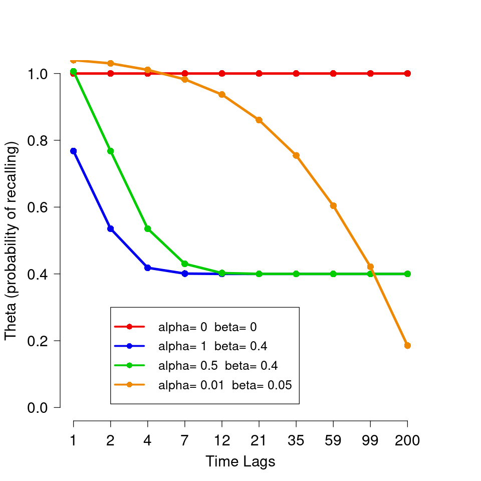

```r
rm(list=ls())
# Analyzing the core model
tm <- c(1,2,4,7,12,21,35,59,99,200)

alpha_1 <- 0
beta_1 <- 0
th_1 <- exp(-alpha_1*tm)+beta_1
col_1 <- '#ee0000'

alpha_2 <- 1
beta_2 <- 0.4
col_2 <- '#0000ee'
th_2 <- exp(-alpha_2*tm)+beta_2

alpha_3 <- .5
beta_3 <- .4
col_3 <- '#00cc00'
th_3 <- exp(-alpha_3*tm)+beta_3

alpha_4 <- 0.01
beta_4 <- 0.05
col_4 <- '#ee8800'
th_4 <- exp(-alpha_4*tm)+beta_4


options(repr.plot.width = 8, repr.plot.height = 8) # Plot size in notebook
par(mar=rep(5,4))
plot(NULL,ylim=c(0,1),xlim=c(1,length(tm)),axes=F,ann=F)
lines(1:length(tm),th_1,col=col_1,lwd=4,type='o',pch=16,cex=1.5)
lines(1:length(tm),th_2,col=col_2,lwd=4,type='o',pch=16,cex=1.5)
lines(1:length(tm),th_3,col=col_3,lwd=4,type='o',pch=16,cex=1.5)
lines(1:length(tm),th_4,col=col_4,lwd=4,type='o',pch=16,cex=1.5)
axis(1,at=1:length(tm),labels=tm,cex.axis=1.5,padj=0.25)
axis(2,cex.axis=1.5,las=1)
mtext('Time Lags',1,cex=1.5,line=3)
mtext('Theta (probability of recalling)',2,cex=1.5,line=3.5)
legend(2,.3,
       legend=c(paste('alpha=',alpha_1,' beta=',beta_1),
               paste('alpha=',alpha_2,' beta=',beta_2),
               paste('alpha=',alpha_3,' beta=',beta_3),
               paste('alpha=',alpha_4,' beta=',beta_4)),
       cex=1.25,
       col=c(col_1,col_2,col_3,col_4),
       text.width=3.6,
       bg='#ffffffcc',
       lwd=3,pch=16)
```

En tanto que las características de memoria $\alpha$ y $\beta$ no son observables, pero su valor es relevante respecto de cierta teoría psicológica, es conveniente calcular sus valores más probables a la luz de las observaciones del experimento.

Las células siguientes muestran cómo calcular dicha incertidumbre y reproducen los resultados reportados en las publicaciones originales. En particular, reproducimos las diferentes "versiones" del mismo modelo de decaimiento exponencial central, que comienzan con **1.** un modelo que no admite diferencias individuales y sólo calcula una tasa de decaimiento $\alpha$ y una línea base de recuerdo $\beta$ globales utilizando todas las observaciones disponibles, continúan con **2.** un modelo que infiere una tasa de decaimiento y una línea base de recuerdo para cada participante, reconociendo posibles diferencias individuales, pero que ignora la relación entre los distintos participantes, para finalmente presentar **3.** un modelo que infiere un parámetro $\alpha$ y $\beta$ para cada persona pero que aparte supone cierta estructura jerárquica entre ellas que permite hacer predicciones sensibles sobre cómo se comportará una persona todavía no observada.

#### Observaciones

```r
rm(list=ls())

# Observed
n <- 18 # Number of words presented to participants
t <- c(1,2,4,7,12,21,35,59,99,200) # Time lags after which participants recall
n_times <- length(t) # Number of time lags
n_subjs <- 4 # Number of subjects

y <- array(dim=c(n_subjs,n_times)) # Number of words recalled by each participant after each lag
y[1,] <- c(18,18,16,13,9,6,4,4,4,NA)
y[2,] <- c(17,13,9,6,4,4,4,4,4,NA)
y[3,] <- c(14,10,6,4,4,4,4,4,4,NA)
y[4,] <- NA

print(y)
```

```
     [,1] [,2] [,3] [,4] [,5] [,6] [,7] [,8] [,9] [,10]
[1,]   18   18   16   13    9    6    4    4    4    NA
[2,]   17   13    9    6    4    4    4    4    4    NA
[3,]   14   10    6    4    4    4    4    4    4    NA
[4,]   NA   NA   NA   NA   NA   NA   NA   NA   NA    NA
```

#### Objetos de `JAGS` comunes para todos los modelos

```r
# Observed (all models work with the same data)
data_jags <- list('y','n','t','n_times','n_subjs')

# Unobserved (these labels are consistent across models)
unobs <- c('y_post','alpha_post','beta_post',
           'y_prior','alpha_prior','beta_prior',
           'mu_alpha_prior','mu_alpha_post',
           'mu_beta_prior','mu_beta_post',
           'lambda_beta_prior','lambda_beta_post',
           'lambda_alpha_prior','lambda_alpha_post')
```

#### Modelo 1: $\alpha$ y $\beta$ globales (sin diferencias individuales)

$$\begin{align} \alpha&\sim Beta(1,1)\\ \beta&\sim Beta(1,1)\\ \theta_{ij}&\leftarrow e^{-\alpha t_j}+\beta\\ y_{ij}&\overset{\tiny{iid}}{\sim} Binomial(\theta_{ij},n)\\ \end{align}$$

[figure not shown]

```r
# Model 1: no individual differences
write('

model{

alpha_prior~dbeta(1,1)
beta_prior~dbeta(1,1)
alpha_post~dbeta(1,1)
beta_post~dbeta(1,1)

for(j in 1:n_times){
  for(i in 1:n_subjs){
    theta_prior[i,j] <- min(.99,exp(-alpha_prior*t[j])+beta_prior)
    theta_post[i,j] <- min(.99,exp(-alpha_post*t[j])+beta_post)

    # La siguiente línea (17) no establece el límite superior de la función exponencial
    # (descomentarla Y comentar la línea 13 para generar el error de consistencia)
    #theta_post[i,j] <- exp(-alpha_post*t[j])+beta_post

    y_prior[i,j]~dbin(theta_prior[i,j],n)
    y[i,j]~dbin(theta_post[i,j],n)
    y_post[i,j]~dbin(theta_post[i,j],n)
  }
}

}
','no_individual_differences.bug')

# Inference over Model 1
library('R2jags')
bayes_no_ind_diff <- jags(data=data_jags,
                          parameters.to.save=unobs,
                          model.file='no_individual_differences.bug',
                          n.iter=80000,
                          n.burnin=20000,
                          n.thin=10)
nds_no_ind_diff <- bayes_no_ind_diff$BUGSoutput$sims.list
```

```
Linked to JAGS 4.3.0

Loaded modules: basemod,bugs




module glm loaded
```

[output not shown]

#### Modelo 2: $\alpha$ y $\beta$ individuales (sin relación jerárquica entre personas)

$$\begin{align} \alpha_i&\overset{\tiny{iid}}{\sim} Beta(1,1)\\ \beta_i&\overset{\tiny{iid}}{\sim} Beta(1,1)\\ \theta_{ij}&\leftarrow e^{-\alpha_i t_j}+\beta_i\\ y_{ij}&\overset{\tiny{iid}}{\sim} Binomial(\theta_{ij},n)\\ \end{align}$$

[figure not shown]

```r
# Model 2: non-structured individual differences
write('

model{

for(i in 1:n_subjs){
  alpha_prior[i]~dbeta(1,1)
  beta_prior[i]~dbeta(1,1)
  alpha_post[i]~dbeta(1,1)
  beta_post[i]~dbeta(1,1)

  for(j in 1:n_times){
    theta_prior[i,j] <- min(.99,exp(-alpha_prior[i]*t[j])+beta_prior[i])
    theta_post[i,j] <- min(.99,exp(-alpha_post[i]*t[j])+beta_post[i])

    y_prior[i,j]~dbin(theta_prior[i,j],n)
    y[i,j]~dbin(theta_post[i,j],n)
    y_post[i,j]~dbin(theta_post[i,j],n)
  }
}

}
','individual_differences.bug')

# Inference over Model 2
bayes_ind_diff <- jags(data=data_jags,
                       parameters.to.save=unobs,
                       model.file='individual_differences.bug',
                       n.iter=80000,
                       n.burnin=20000,
                       n.thin=10)
nds_ind_diff <- bayes_ind_diff$BUGSoutput$sims.list
```

[output not shown]

#### Modelo 3: $\alpha$ y $\beta$ individuales pero con relación jerárquica

$$\begin{align} \mu_\alpha&\sim Beta(1,1)\\ \lambda_\alpha&\sim Gamma(0.001,0.001)\\ \mu_\beta&\sim Beta(1,1)\\ \lambda_\beta&\sim Gamma(0.001,0.001)\\ \alpha_i&\overset{\tiny{iid}}{\sim} Normal(\mu_\alpha,\lambda_\alpha)T(0,1)\\ \beta_i&\overset{\tiny{iid}}{\sim} Normal(\mu_\beta,\lambda_\beta)T(0,1)\\ \theta_{ij}&\leftarrow e^{-\alpha_i t_j}+\beta_i\\ y_{ij}&\overset{\tiny{iid}}{\sim} Binomial(\theta_{ij},n)\\ \end{align}$$

[figure not shown]

```r
# Model 3: Hierarchical individual differences
write('

model{

# Parents of Decay Rate (alpha)
mu_alpha_post~dbeta(1,1)
mu_alpha_prior~dbeta(1,1)
lambda_alpha_post~dgamma(0.001,0.001)T(0.01,)
lambda_alpha_prior~dgamma(0.001,0.001)T(0.01,)

# Parents of Baseline (beta)
mu_beta_post~dbeta(1,1)
mu_beta_prior~dbeta(1,1)
lambda_beta_post~dgamma(0.001,0.001)T(0.01,)
lambda_beta_prior~dgamma(0.001,0.001)T(0.01,)

for(i in 1:n_subjs){
  alpha_prior[i]~dnorm(mu_alpha_prior,lambda_alpha_prior)T(0,1)
  alpha_post[i]~dnorm(mu_alpha_post,lambda_alpha_post)T(0,1)
  beta_prior[i]~dnorm(mu_beta_prior,lambda_beta_prior)T(0,1)
  beta_post[i]~dnorm(mu_beta_post,lambda_beta_post)T(0,1)

  for(j in 1:n_times){
    theta_prior[i,j] <- min(.99,exp(-alpha_prior[i]*t[j])+beta_prior[i])
    theta_post[i,j] <- min(.99,exp(-alpha_post[i]*t[j])+beta_post[i])

    y_prior[i,j]~dbin(theta_prior[i,j],n)
    y[i,j]~dbin(theta_post[i,j],n)
    y_post[i,j]~dbin(theta_post[i,j],n)
  }
}

}
','hier_individual_differences.bug')

# Inference over Model 3
bayes_hier_ind_diff <- jags(data=data_jags,
                       parameters.to.save=unobs,
                       model.file='hier_individual_differences.bug',
                       n.iter=80000,
                       n.burnin=20000,
                       n.thin=10)
nds_hier_ind_diff <- bayes_hier_ind_diff$BUGSoutput$sims.list
```

```r
cat('\n')
print('Modelo 1:')
summary(bayes_no_ind_diff$BUGSoutput$summary[,'Rhat'])
summary(bayes_no_ind_diff$BUGSoutput$summary[,'n.eff'])
cat('\n')
print('Modelo 2:')
summary(bayes_ind_diff$BUGSoutput$summary[,'Rhat'])
summary(bayes_ind_diff$BUGSoutput$summary[,'n.eff'])
cat('\n')
print('Modelo 3:')
summary(bayes_hier_ind_diff$BUGSoutput$summary[,'Rhat'])
summary(bayes_hier_ind_diff$BUGSoutput$summary[,'n.eff'])
```

```
[1] "Modelo 1:"
```

```
   Min. 1st Qu.  Median    Mean 3rd Qu.    Max.
  1.001   1.001   1.001   1.001   1.001   1.001
```

```
   Min. 1st Qu.  Median    Mean 3rd Qu.    Max.
   4800   15000   18000   15856   18000   18000
```

```
[1] "Modelo 2:"
```

```
   Min. 1st Qu.  Median    Mean 3rd Qu.    Max.
  1.001   1.001   1.001   1.001   1.001   1.001
```

```
   Min. 1st Qu.  Median    Mean 3rd Qu.    Max.
   4300   13000   18000   15204   18000   18000
```

```
[1] "Modelo 3:"
```

```
   Min. 1st Qu.  Median    Mean 3rd Qu.    Max.
  1.001   1.001   1.001   1.001   1.001   1.003
```

```
   Min. 1st Qu.  Median    Mean 3rd Qu.    Max.
   1800   12000   18000   14586   18000   18000
```

#### Distribuciones Postdictivas

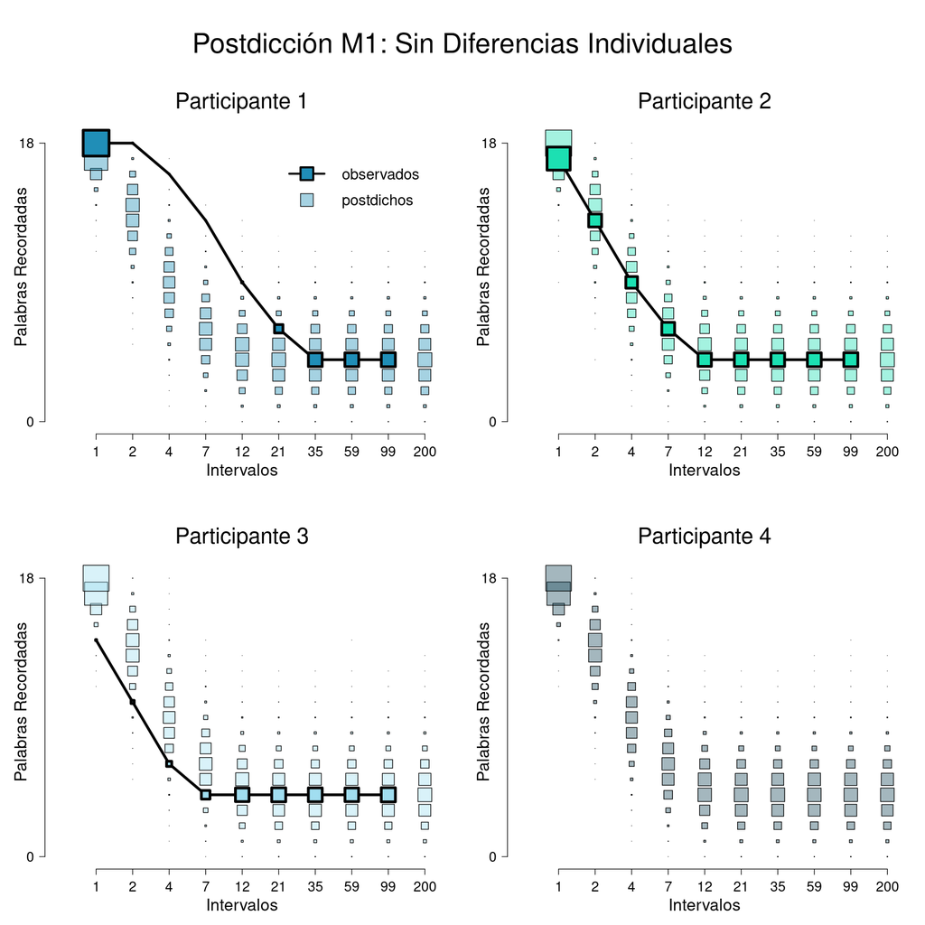

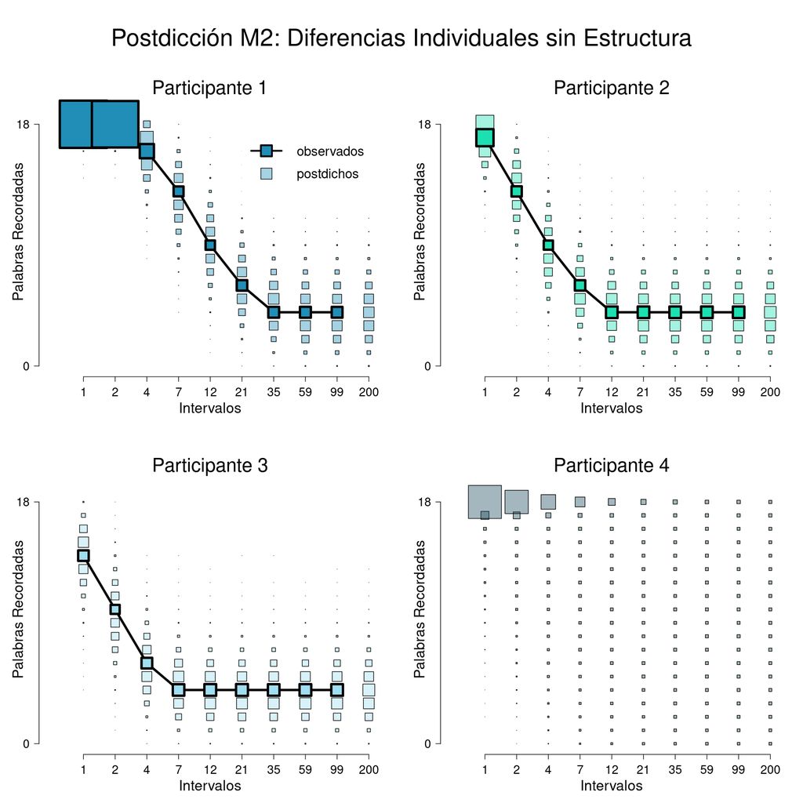

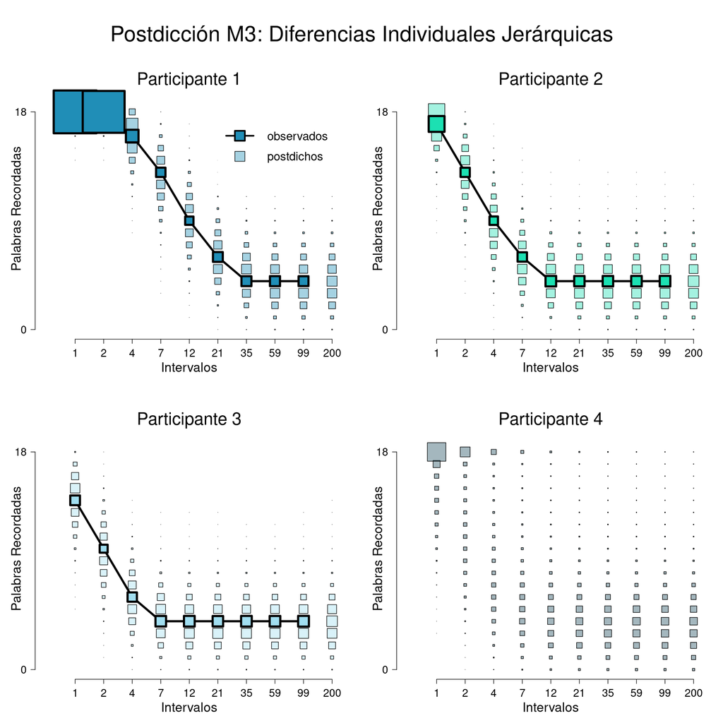

```r
# Plotting
par_cols <- c("#208eb7", "#1ce0b2", "#a1def0", "#1c4c5e")

# Plotting Postdictions
plot_postdiction <- function(nds,title){
  time <- t
  # Predictive Distributions
  options(repr.plot.width = 14, repr.plot.height = 14) # Plot size in notebook
  layout(matrix(1:4,ncol=2,byrow = T))
  par(oma=c(0,0,5,0))
  for(subj in 1:4){
    plot(NULL,xlim=c(0,n_times),ylim=c(0,n+2),axes=F,ann=F)
    axis(1,at=1:n_times,labels=time,padj=0.25,cex.axis=1.5)
    axis(2,at=c(0,18),las=1,cex.axis=1.5)
    mtext('Intervalos',1,line=3,cex=1.5)
    mtext('Palabras Recordadas',2,line=1.5,cex=1.5)
    mtext(paste('Participante',subj),3,line=-1,cex=2)
    data_size <- NULL
    for(t in 1:n_times){
      hist(nds$y_post[,subj,t],breaks=seq(-.5,n+.5,1),plot=F)->ht
      #hist(nds$y_prior[,subj,t],breaks=seq(-.5,n+.5,1),plot=F)->ht
      point_size <- ht$density*18
      points(rep(t,n+1),ht$mids,cex=point_size,pch=22,bg=paste(par_cols[subj],'66',sep=''))
      data_size <- append(data_size,point_size[which(0:n==y[subj,t])])
    }
    lines(1:n_times,y[subj,],cex=data_size,type='o',bg=par_cols[subj],pch=22,lwd=4)

    # Adds legend exclusively in first plot
    if(subj==1){
      legend(6,19,
             legend=c('observados','postdichos'),
             lty=c('solid','blank'),
             lwd=c(3,1),
             pt.bg=c(par_cols[subj],paste(par_cols[subj],'66',sep='')),
             pch=22,
             pt.cex=3.5,
             text.width=2.5,
             y.intersp=.4,
             x.intersp=.5,
             cex=1.65,
             seg.len=1,
             box.lty='blank')
    }
  }
  mtext(title,3,outer=T,line=0,cex=2.5)
}

plot_postdiction(nds_no_ind_diff,'Postdicción M1: Sin Diferencias Individuales')
plot_postdiction(nds_ind_diff,'Postdicción M2: Diferencias Individuales sin Estructura')
plot_postdiction(nds_hier_ind_diff,'Postdicción M3: Diferencias Individuales Jerárquicas')
```

#### Interpretación (del Modelo 3)

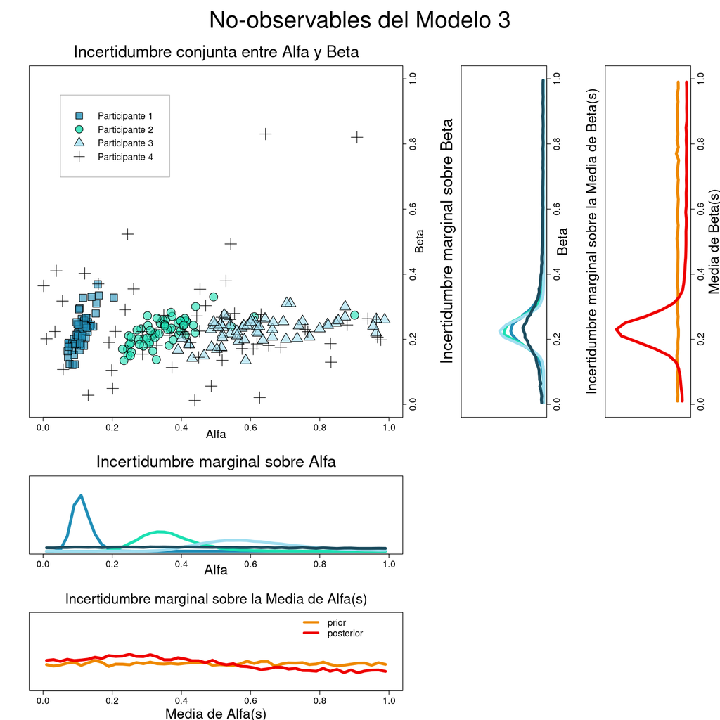

```r
nds <- nds_hier_ind_diff

options(repr.plot.width = 13, repr.plot.height = 13) # Plot size in notebook
layout(matrix(c(1,2,4,3,0,0,5,0,0),nrow=3,ncol=3),
       widths = c(3,1,1),heights = c(3,1,1))
par(mar=rep(4,4),oma=c(0,0,5,0))
# Joint uncertainty over non-observables Alpha and Beta
plot(NULL,xlim=c(0,1),ylim=c(0,1),axes=F,ann=F)
axis(1,cex.axis=1.5)
axis(4,cex.axis=1.5)
mtext('Incertidumbre conjunta entre Alfa y Beta',3,line=1,cex=1.75)
mtext('Alfa',1,line=2,cex=1.25)
mtext('Beta',4,line=2,cex=1.25)
box()
pt_chr <- c(22,21,24,3)
par_cols <- c("#208eb7", "#1ce0b2", "#a1def0", "#1c4c5e")
indx <- sample(1:dim(nds$alpha_post)[1],size=60)
num_subj <- dim(nds$alpha_post)[2]
for(i in 1:num_subj){
    points(nds$alpha_post[indx,i],nds$beta_post[indx,i],
   #points(nds$alpha_prior[indx,i],nds$beta_prior[indx,i],
         pch=pt_chr[i],bg=paste(par_cols[i],'99',sep=''),
         cex=3)
}
legend(0.05,0.95,
       legend=paste('Participante',1:4),
       pt.bg=paste(par_cols,'cc',sep=''),
       pch=pt_chr,
       pt.cex=2.75,
       box.col = '#aaaaaa',
       text.width=.18,
       y.intersp=.5,
       cex=1.5)
# Uncertainty over ALPHA
plot(NULL,xlim=c(0,1),ylim=c(0,20),axes=F,ann=F)
mtext('Incertidumbre marginal sobre Alfa',3,line=1,cex=1.75)
mtext('Alfa',1,line=2,cex=1.5)
axis(1,cex.axis=1.5)
box()
for(i in 1:num_subj){
  hist(nds$alpha_post[,i],breaks=seq(0,1,.02),plot=F)->ht
  #hist(nds$alpha_prior[,i],breaks=seq(0,1,.02),plot=F)->ht
  lines(ht$mids,ht$density,col=par_cols[i],lwd=5)
}
# Uncertainty over BETA
plot(NULL,ylim=c(0,1),xlim=c(-20,0),axes=F,ann=F)
mtext('Incertidumbre marginal sobre Beta',2,line=1,cex=1.75)
mtext('Beta',4,line=2,cex=1.5)
axis(4,cex.axis=1.5)
box()
for(i in 1:dim(nds$beta_post)[2]){
  hist(nds$beta_post[,i],breaks=seq(0,1,.01),plot=F)->ht
  #hist(nds$beta_prior[,i],breaks=seq(0,1,.01),plot=F)->ht
  lines(-ht$density,ht$mids,col=par_cols[i],lwd=5)
}
# Uncertainty over the MEAN of Alphas
plot(NULL,xlim=c(0,1),ylim=c(0,3),axes=F,ann=F)
mtext('Incertidumbre marginal sobre la Media de Alfa(s)',3,line=1,cex=1.5)
mtext('Media de Alfa(s)',1,line=3,cex=1.5)
axis(1,cex.axis=1.5)
box()
hist(nds$mu_alpha_post,breaks=seq(0,1,.02),plot=F)->ht_post
hist(nds$mu_alpha_prior,breaks=seq(0,1,.02),plot=F)->ht_prior
lines(ht_prior$mids,ht_prior$density,col='#ee8800',lwd=5)
lines(ht_post$mids,ht_post$density,col='#ee0000',lwd=5)
legend(.7,2.5,legend=c('prior','posterior'),
      col=c('#ee8800','#ee0000'),lwd=4,box.lty='blank',bg=NULL,
      cex=1.5,yjust=0.5,y.intersp=.1,x.intersp=0.5,
      seg.len=0.75)
# Uncertainty over BETA
plot(NULL,ylim=c(0,1),xlim=c(-8,0),axes=F,ann=F)
mtext('Incertidumbre marginal sobre la Media de Beta(s)',2,line=1,cex=1.5)
mtext('Media de Beta(s)',4,line=3,cex=1.5)
axis(4,cex.axis=1.5)
box()
hist(nds$mu_beta_post,breaks=seq(0,1,.02),plot=F)->ht_post
hist(nds$mu_beta_prior,breaks=seq(0,1,.02),plot=F)->ht_prior
lines(-ht_prior$density,ht_prior$mids,col='#ee8800',lwd=5)
lines(-ht_post$density,ht_post$mids,col='#ee0000',lwd=5)

# Title
mtext('No-observables del Modelo 3',3,outer=T,line=1,cex=2.5)
```

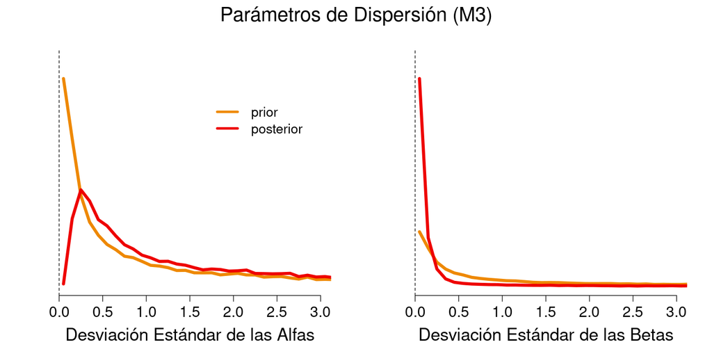

```r
options(repr.plot.width = 12, repr.plot.height = 6) # Plot size in notebook
layout(matrix(1:2,ncol=2))
# Standard Deviation of Alpha
hist(1/(nds$lambda_alpha_prior)^(1/2),breaks=seq(0,100,0.1),plot=F)->ht_sd_alpha_prior
hist(1/(nds$lambda_alpha_post)^(1/2),breaks=seq(0,100,0.1),plot=F)->ht_sd_alpha_post
plot(NULL,xlim=c(0,3),ylim=c(0,max(max(ht_sd_alpha_prior$density),max(ht_sd_alpha_post$density))*1.1),axes=F,ann=F)
lines(ht_sd_alpha_prior$mids,ht_sd_alpha_prior$density,col='#ee8800',lwd=5)
lines(ht_sd_alpha_post$mids,ht_sd_alpha_post$density,col='#ee0000',lwd=5)
abline(v=0,lty='dashed')
axis(1,cex.axis=1.5)
mtext('Desviación Estándar de las Alfas',1,line=3,cex=1.75)
legend(1.5,max(max(ht_sd_alpha_prior$density),max(ht_sd_alpha_post$density))*0.8,
       legend=c('prior','posterior'),
      col=c('#ee8800','#ee0000'),lwd=4,box.lty='blank',bg=NULL,
      cex=1.35,yjust=0.5,y.intersp=1.2,x.intersp=0.5,
      seg.len=0.75)
# Standard Deviation of Beta
hist(1/(nds$lambda_beta_prior)^(1/2),breaks=seq(0,100,0.1),plot=F)->ht_sd_beta_prior
hist(1/(nds$lambda_beta_post)^(1/2),breaks=seq(0,100,0.1),plot=F)->ht_sd_beta_post
plot(NULL,xlim=c(0,3),ylim=c(0,max(max(ht_sd_beta_prior$density),max(ht_sd_beta_post$density))*1.1),axes=F,ann=F)
lines(ht_sd_beta_prior$mids,ht_sd_beta_prior$density,col='#ee8800',lwd=5)
lines(ht_sd_beta_post$mids,ht_sd_beta_post$density,col='#ee0000',lwd=5)
abline(v=0,lty='dashed')
axis(1,cex.axis=1.5)
mtext('Desviación Estándar de las Betas',1,line=3,cex=1.75)
# Title
mtext('Parámetros de Dispersión (M3)',outer=T,line=-2,cex=2)
```

### Modelo Logístico

La ecuación central de los modelos anteriores especifica el cambio en cierta probabilidad $\in(0,1)$ como función de cierta variable $\in\mathbb{R}$, en donde dicha función tiene una "forma exponencial". En los apuntes anteriores hemos estudiado otro tipo de funciones que permiten modelar el mismo tipo de relaciones, lo que convierte a los **modelos logísticos** en posibles candidatos para explicar este conjunto de observaciones.

En las células siguientes mostramos cómo implementar dicho cambio utilizando extensiones jerárquicas sobre el modelo logístico de 4 parámetros, enfatizando las diferencias resultantes en la distribución postdictiva de cada función (exponencial vs. logística) y apuntando hacia las diferencias en la interpretación de cada modelo.

$$\begin{align} \mu_a&\sim Normal(0,\lambda=0.1)\\ \lambda_a&\sim Gamma(0.001,0.001)\\ \mu_b&\sim Norma(50,\lambda=0.01)\\ \lambda_b&\sim Gamma(0.001,0.001)\\ \alpha_c&\sim Normal(0,1)T(0.8,)\\ \beta_c&\sim Normal(0,1)T(0.8,)\\ \alpha_d&\sim Normal(0,1)T(0.8,)\\ \beta_d&\sim Normal(0,1)T(0.8,)\\ a_i&\overset{\tiny{iid}}{\sim} Normal(\mu_a,\lambda_a)\\ b_i&\overset{\tiny{iid}}{\sim} Normal(\mu_b,\lambda_b)\\ c_i&\overset{\tiny{iid}}{\sim} Beta(\alpha_c,\beta_c)T(0,0.5)\\ d_i&\overset{\tiny{iid}}{\sim} Beta(\alpha_d,\beta_d)T(0.5,1)\\ \theta_{ij}&\leftarrow c_i+\frac{d_i-c_i}{1+e^{-a_i(t_j-b_i)}}\\ y_{ij}&\overset{\tiny{iid}}{\sim} Binomial(\theta_{ij},n)\\ \end{align}$$

[figure not shown]

```r
# Unobserved (new variables for this model)
unobs <- c('mu_a_post','mu_a_prior',
          'lambda_a_post','lambda_a_prior',
          'mu_b_post','mu_b_prior',
          'lambda_b_post','lambda_b_prior',
          'alpha_c_prior','alpha_c_post',
          'beta_c_prior','beta_c_post',
          'alpha_d_prior','alpha_d_post',
          'beta_d_prior','beta_d_post',
          'a_post','a_prior',
          'b_post','b_prior',
          'c_post','c_prior',
          'd_post','d_prior',
          'theta_prior','theta_post',
          'y_prior','y_post')

# Logistic Curve + Hierarchical Individual Differences
write('

model{

# Parents of Logistic Slopes (a)
mu_a_post~dnorm(0,.1)
mu_a_prior~dnorm(0,.1)
lambda_a_post~dgamma(0.001,0.001)T(0.01,)
lambda_a_prior~dgamma(0.001,0.001)T(0.01,)

# Parents of Logistic Mid-Points (b)
mu_b_post~dnorm(50,.01)
mu_b_prior~dnorm(50,.01)
lambda_b_post~dgamma(0.001,0.001)T(0.01,)
lambda_b_prior~dgamma(0.001,0.001)T(0.01,)

# Parents of Logistic Lower Asymptote (c)
alpha_c_prior~dnorm(0,1)T(0.8,)
alpha_c_post~dnorm(0,1)T(0.8,)
beta_c_prior~dnorm(0,1)T(0.8,)
beta_c_post~dnorm(0,1)T(0.8,)

# Parents of Logistic Upper Asymptote (d)
alpha_d_prior~dnorm(0,1)T(0.8,)
alpha_d_post~dnorm(0,1)T(0.8,)
beta_d_prior~dnorm(0,1)T(0.8,)
beta_d_post~dnorm(0,1)T(0.8,)

for(i in 1:n_subjs){
  a_prior[i]~dnorm(mu_a_prior,lambda_a_prior)
  a_post[i]~dnorm(mu_a_post,lambda_a_post)
  b_prior[i]~dnorm(mu_b_prior,lambda_b_prior)
  b_post[i]~dnorm(mu_b_post,lambda_b_post)
  c_prior[i]~dbeta(alpha_c_prior,beta_c_prior)T(0,0.5)
  c_post[i]~dbeta(alpha_c_post,beta_c_post)T(0,0.5)
  d_prior[i]~dbeta(alpha_d_prior,beta_d_prior)T(0.5,1)
  d_post[i]~dbeta(alpha_d_post,beta_d_post)T(0.5,1)

  for(j in 1:n_times){
    theta_prior[i,j] <- c_prior[i]+(d_prior[i]-c_prior[i])*(1/(1+exp(-a_prior[i]*(t[j]-b_prior[i]))))
    theta_post[i,j] <- c_post[i]+(d_post[i]-c_post[i])*(1/(1+exp(-a_post[i]*(t[j]-b_post[i]))))
    y_prior[i,j]~dbin(theta_prior[i,j],n)
    y[i,j]~dbin(theta_post[i,j],n)
    y_post[i,j]~dbin(theta_post[i,j],n)
  }
}

}
','logistic_memory.bug')

# Inference over Model 4
library('R2jags')
set.seed(26)
bayes_logistic <- jags(data=data_jags,
                       parameters.to.save=unobs,
                       model.file='logistic_memory.bug',
                       n.iter=80000,
                       n.burnin=20000,
                       n.thin=10)
nds_logistic <- bayes_logistic$BUGSoutput$sims.list
```

```r
cat('\n')
print('Modelo 4:')
summary(bayes_logistic$BUGSoutput$summary[,'Rhat'])
summary(bayes_logistic$BUGSoutput$summary[,'n.eff'])
```

```
[1] "Modelo 4:"
```

```
   Min. 1st Qu.  Median    Mean 3rd Qu.    Max.
  1.001   1.001   1.001   1.001   1.001   1.007
```

```
   Min. 1st Qu.  Median    Mean 3rd Qu.    Max.
   1300   12000   18000   14625   18000   18000
```

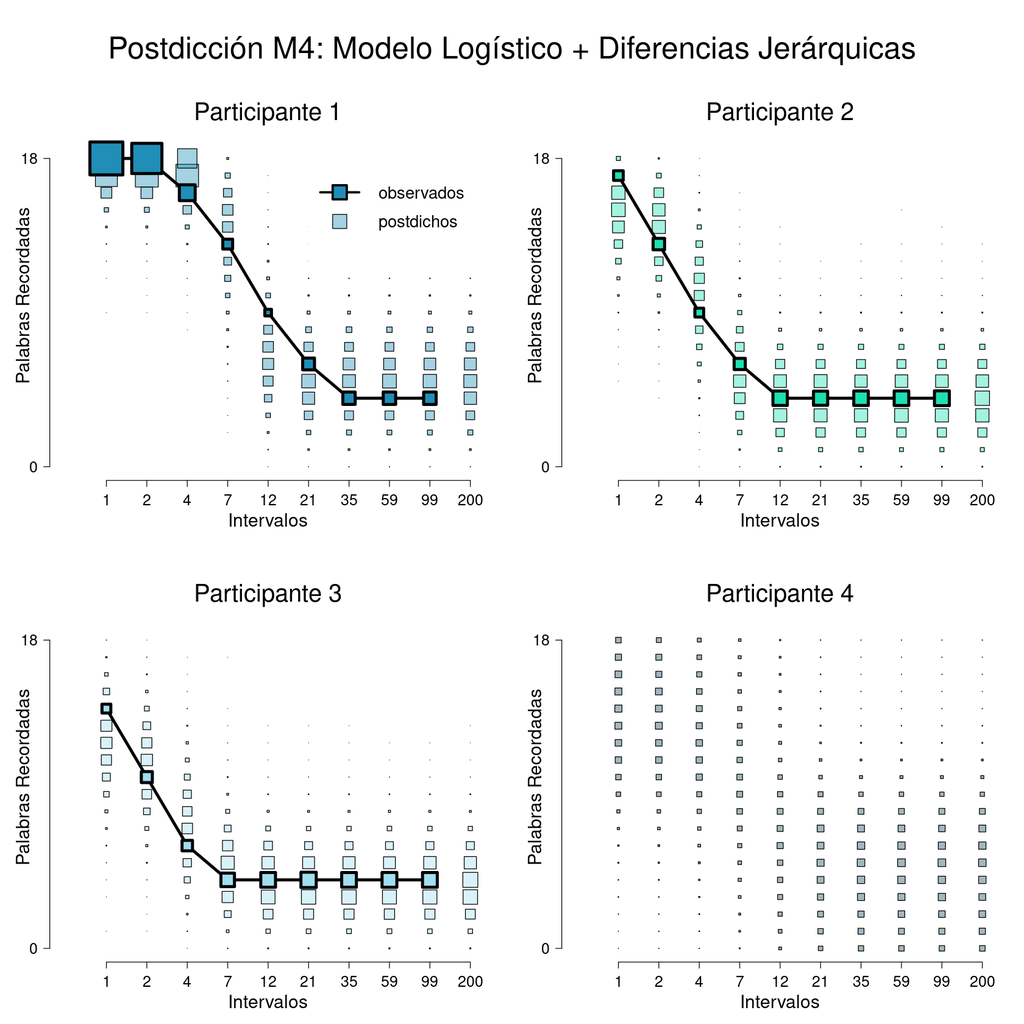

```r
plot_postdiction(nds_logistic,'Postdicción M4: Modelo Logístico + Diferencias Jerárquicas')
```

#### Interpretación Modelos 3 y 4

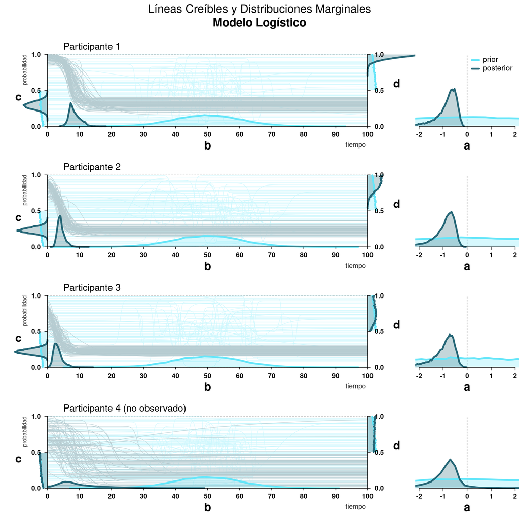

```r
# Marginal Distributions LOGISTIC MODEL

col_prior <- '#65e6f9'
col_post <- '#256676'

options(repr.plot.width = 15, repr.plot.height = 15)
layout(matrix(1:8,ncol=2,byrow = T),widths = c(4,1))
par(cex.axis=1.75,mgp=c(2,1.5,0),mar=c(4,0,2,0),oma=c(2,0,6,0))

subj_labels <- paste('Participante',1:4,c(rep('',3),'(no observado)'))

for(subj in 1:4){

  plot(NULL,xlim=c(-10,110),ylim=c(0,1.2),axes=F,ann=F)
  segments(x0=rep(0,2),x1=rep(100,2),y0=c(0,1),y1=c(0,1),lty='dashed')

  # indexes in JAGS to plot:
  index <- sample(1:dim(nds_logistic$a_post)[1],size=80)
  x_plot <- seq(0,100,0.01)
  for(i in index){
    a_prior <- nds_logistic$a_prior[i,subj]
    b_prior <- nds_logistic$b_prior[i,subj]
    c_prior <- nds_logistic$c_prior[i,subj]
    d_prior <- nds_logistic$d_prior[i,subj]
    p_y_prior <- c_prior+(d_prior-c_prior)/(1+exp(-a_prior*(x_plot-b_prior)))
    lines(x_plot,p_y_prior,col=col_prior)
  }
  for(i in index){
    a_post <- nds_logistic$a_post[i,subj]
    b_post <- nds_logistic$b_post[i,subj]
    c_post <- nds_logistic$c_post[i,subj]
    d_post <- nds_logistic$d_post[i,subj]
    p_y_post <- c_post+(d_post-c_post)/(1+exp(-a_post*(x_plot-b_post)))
    lines(x_plot,p_y_post,col=col_post)
  }

  clip(0,100,-2,2)
  polygon(x=c(-10,110,110,-10),y=c(-.25,-.25,1.15,1.15),col='#ffffffaa',border=NA)
  text(5,1.1,subj_labels[subj],adj=0,cex=2.5)

  # Uncertainty over b
  b_pst <- hist(nds_logistic$b_post[,subj],breaks=50,plot=F)
  b_prr <- hist(nds_logistic$b_prior[,subj],breaks=50,plot=F)
  prr_dens <- b_prr$density*4
  prr_mids <- b_prr$mids
  pst_dens <- b_pst$density
  pst_mids <- b_pst$mids
  polygon(x=c(head(prr_mids,1),prr_mids,tail(prr_mids,1)),y=c(0,prr_dens,0),
          col=paste(col_prior,'44',sep=''),border=NA)
  polygon(x=c(head(pst_mids,1),pst_mids,tail(pst_mids,1)),y=c(0,pst_dens,0),
          col=paste(col_post,'44',sep=''),border=NA)
  lines(prr_mids,prr_dens,lwd=5,col=col_prior)
  lines(pst_mids,pst_dens,lwd=5,col=col_post)
  mtext('b',1,line=3.5,cex=2,font=2)

  clip(-100,200,-2,2)
  # Uncertainty over c
  c_pst <- hist(nds_logistic$c_post[,subj],breaks=50,plot=F)
  c_prr <- hist(nds_logistic$c_prior[,subj],breaks=50,plot=F)
  prr_dens <- -c_prr$density
  prr_mids <- c_prr$mids
  pst_dens <- -c_pst$density
  pst_mids <- c_pst$mids
  polygon(x=c(0,prr_dens,0),y=c(head(prr_mids,1),prr_mids,tail(prr_mids,1)),
          col=paste(col_prior,'44',sep=''),border=NA)
  polygon(x=c(0,pst_dens,0),y=c(head(pst_mids,1),pst_mids,tail(pst_mids,1)),
          col=paste(col_post,'44',sep=''),border=NA)
  lines(prr_dens,prr_mids,lwd=5,col=col_prior)
  lines(pst_dens,pst_mids,lwd=5,col=col_post)
  text(-9,.4,'c',cex=3,font=2,srt=0)
  text(-7,1,'probabilidad',srt=90,adj=1,cex=1.5,col='#333333')
  mtext('tiempo',1,line=3,adj=.875,cex=1.2,col='#333333')

  # Uncertainty over d
  d_pst <- hist(nds_logistic$d_post[,subj],breaks=50,plot=F)
  d_prr <- hist(nds_logistic$d_prior[,subj],breaks=50,plot=F)
  prr_dens <- 100+d_prr$density
  prr_mids <- d_prr$mids
  pst_dens <- 100+d_pst$density
  pst_mids <- d_pst$mids
  polygon(x=c(100,prr_dens,100),y=c(head(prr_mids,1),prr_mids,tail(prr_mids,1)),
          col=paste(col_prior,'44',sep=''),border=NA)
  polygon(x=c(100,pst_dens,100),y=c(head(pst_mids,1),pst_mids,tail(pst_mids,1)),
          col=paste(col_post,'44',sep=''),border=NA)
  lines(prr_dens,prr_mids,lwd=5,col=col_prior)
  lines(pst_dens,pst_mids,lwd=5,col=col_post)
  text(109,.6,'d',cex=3,font=2,srt=0)

  par(mgp=c(1,1.5,0))
  axis(1,at=seq(0,100,10),pos=0,lwd=1.5,tck=-0.02,font=2)
  par(mgp=c(1,1.5,0))
  axis(2,at=seq(0,1,0.5),las=1,pos=0,lwd=1.5,tck=-0.03,font=2)
  axis(4,at=seq(0,1,0.5),las=1,pos=100,lwd=1.5,tck=-0.03,font=2)

  # Uncertainty over a
  plot(NULL,xlim=c(-2,2),ylim=c(0,3),axes=F,ann=F)
  lines(x=rep(0,2),y=c(0,2.5),lty='dashed')
  a_pst <- hist(nds_logistic$a_post[,subj],breaks=200,plot=F)
  a_prr <- hist(nds_logistic$a_prior[,subj],breaks=200,plot=F)
  prr_dens <- a_prr$density*3
  prr_mids <- a_prr$mids
  pst_dens <- a_pst$density
  pst_mids <- a_pst$mids
  polygon(x=c(head(prr_mids,1),prr_mids,tail(prr_mids,1)),y=c(0,prr_dens,0),
          col=paste(col_prior,'44',sep=''),border=NA)
  polygon(x=c(head(pst_mids,1),pst_mids,tail(pst_mids,1)),y=c(0,pst_dens,0),
          col=paste(col_post,'44',sep=''),border=NA)
  lines(prr_mids,prr_dens,lwd=5,col=col_prior)
  lines(pst_mids,pst_dens,lwd=5,col=col_post)
  mtext('a',1,line=3.5,cex=2,font=2)
  par(mgp=c(1,1.5,0))
  axis(1,pos=0,lwd=1.5,tck=-0.03,font=2)

  if(subj==1){
    segments(x0=rep(0.2,2),x1=rep(0.5,2),y0=c(2.3,2),y1=c(2.3,2),lwd=5,col=c(col_prior,col_post))
    text(0.65,y=c(2,2.3),c('posterior','prior'),cex=2,adj=0)
  }

}

mtext('Líneas Creíbles y Distribuciones Marginales',3,outer=T,line=3,cex=2)
mtext('Modelo Logístico',3,outer=T,line=0,cex=2,font=2)
```

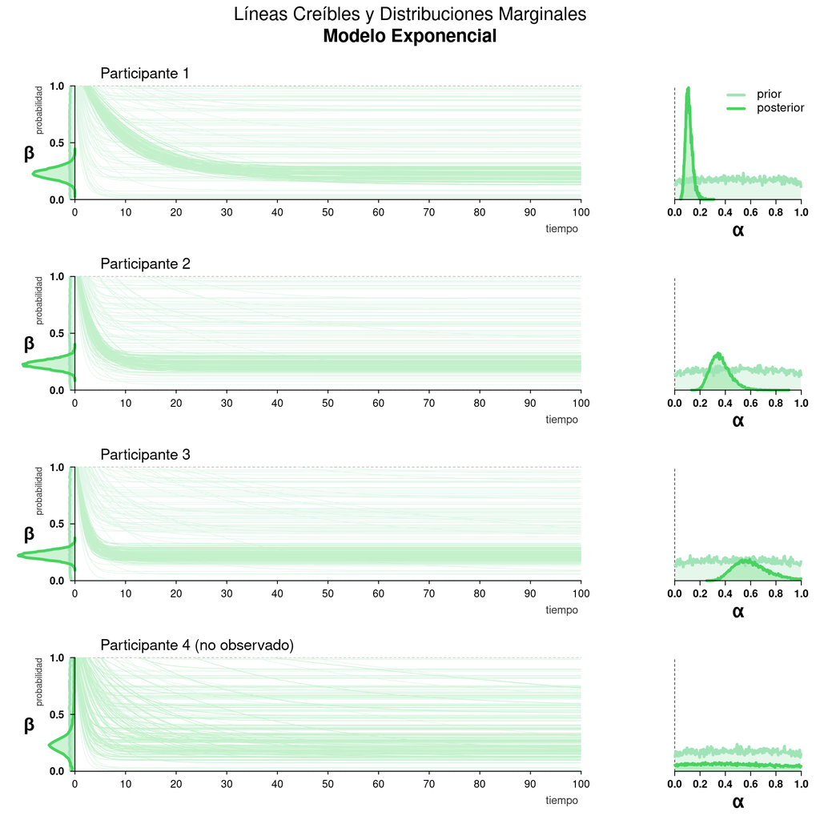

```r
# Marginal Distributions EXPONENTIAL DECAY MODEL

col_prior <- '#a0e3b7'
col_post <- '#49d261'

options(repr.plot.width = 15, repr.plot.height = 15)
layout(matrix(1:8,ncol=2,byrow = T),widths = c(4,1))
par(cex.axis=1.75,mgp=c(2,1.5,0),mar=c(4,0,2,0),oma=c(2,0,6,0))

subj_labels <- paste('Participante',1:4,c(rep('',3),'(no observado)'))

for(subj in 1:4){

  plot(NULL,xlim=c(-10,110),ylim=c(0,1.2),axes=F,ann=F)
  segments(x0=rep(0,2),x1=rep(100,2),y0=c(0,1),y1=c(0,1),lty='dashed')

  # indexes in JAGS to plot:
  index <- sample(1:dim(nds_hier_ind_diff$alpha_post)[1],size=80)
  x_plot <- seq(0,100,0.01)
  clip(0,100,0,1)
  for(i in index){
    alpha_prior <- nds_hier_ind_diff$alpha_prior[i,subj] # 'nds_4pl' makes things readable as well!
    beta_prior <- nds_hier_ind_diff$beta_prior[i,subj]
    p_y_prior <- exp(-alpha_prior*x_plot)+beta_prior
    lines(x_plot,p_y_prior,col=col_prior)
  }
  for(i in index){
    alpha_post <- nds_hier_ind_diff$alpha_post[i,subj]
    beta_post <- nds_hier_ind_diff$beta_post[i,subj]
    p_y_post <- exp(-alpha_post*x_plot)+beta_post
    lines(x_plot,p_y_post,col=col_post)
  }

  clip(-100,200,-2,2)
  polygon(x=c(-10,110,110,-10),y=c(-.25,-.25,1.15,1.15),col='#ffffffaa',border=NA)
  text(5,1.1,subj_labels[subj],adj=0,cex=2.5)

  # Uncertainty over beta (baseline)
  beta_pst <- hist(nds_hier_ind_diff$beta_post[,subj],breaks=50,plot=F)
  beta_prr <- hist(nds_hier_ind_diff$beta_prior[,subj],breaks=50,plot=F)
  prr_dens <- -beta_prr$density
  prr_mids <- beta_prr$mids
  pst_dens <- -beta_pst$density
  pst_mids <- beta_pst$mids
  polygon(x=c(0,prr_dens,0),y=c(head(prr_mids,1),prr_mids,tail(prr_mids,1)),
          col=paste(col_prior,'44',sep=''),border=NA)
  polygon(x=c(0,pst_dens,0),y=c(head(pst_mids,1),pst_mids,tail(pst_mids,1)),
          col=paste(col_post,'44',sep=''),border=NA)
  lines(prr_dens,prr_mids,lwd=5,col=col_prior)
  lines(pst_dens,pst_mids,lwd=5,col=col_post)
  text(-9,.4,'\u03b2',cex=3,font=2,srt=0)
  text(-7,1,'probabilidad',srt=90,adj=1,cex=1.5,col='#333333')
  mtext('tiempo',1,line=3,adj=.875,cex=1.2,col='#333333')

  par(mgp=c(1,1.5,0))
  axis(1,at=seq(0,100,10),pos=0,lwd=1.5,tck=-0.02,font=1)
  par(mgp=c(1,1.5,0))
  axis(2,at=seq(0,1,0.5),las=1,pos=0,lwd=1.5,tck=-0.03,font=2)

  # Uncertainty over alpha (decay rate)
  plot(NULL,xlim=c(-.1,1.1),ylim=c(0,21),axes=F,ann=F)
  lines(x=rep(0,2),y=c(0,5*21/6),lty='dashed')
  alpha_pst <- hist(nds_hier_ind_diff$alpha_post[,subj],breaks=200,plot=F)
  alpha_prr <- hist(nds_hier_ind_diff$alpha_prior[,subj],breaks=200,plot=F)
  prr_dens <- alpha_prr$density*3
  prr_mids <- alpha_prr$mids
  pst_dens <- alpha_pst$density
  pst_mids <- alpha_pst$mids
  polygon(x=c(head(prr_mids,1),prr_mids,tail(prr_mids,1)),y=c(0,prr_dens,0),
          col=paste(col_prior,'44',sep=''),border=NA)
  polygon(x=c(head(pst_mids,1),pst_mids,tail(pst_mids,1)),y=c(0,pst_dens,0),
          col=paste(col_post,'44',sep=''),border=NA)
  lines(prr_mids,prr_dens,lwd=5,col=col_prior)
  lines(pst_mids,pst_dens,lwd=5,col=col_post)
  mtext('\u03b1',1,line=3.5,cex=2,font=2)
  par(mgp=c(1,1.5,0))
  axis(1,pos=0,lwd=1.5,tck=-0.03,font=2)

  if(subj==1){
    segments(x0=rep(0.42,2),x1=rep(0.55,2),y0=c(16.1,14),y1=c(16.1,14),lwd=5,col=c(col_prior,col_post))
    text(0.65,y=c(14,16.1),c('posterior','prior'),cex=2,adj=0)
  }

}

mtext('Líneas Creíbles y Distribuciones Marginales',3,outer=T,line=3,cex=2)
mtext('Modelo Exponencial',3,outer=T,line=0,cex=2,font=2)
```

En general, cada modelo probabilístico/estadístico puede entenderse como una "lente" que permite ver y resaltar diferentes aspectos de los datos y del fenómeno en estudio. Concediendo la analogía, modelar estadísticamente requiere observar los mismos datos con diferentes lentes (uno que permite ver luz normal, otro para luz infrarroja, etcétera) con tal de aprender tanto como sea posible sobre el **fenómeno** bajo estudio.